# IODS course project

Pirre

# About the project/ week 1

*Write a short description about the course and add a link to your github repository here. This is an R markdown (.Rmd) file so you can use R markdown syntax. See the ‘Useful links’ page in the mooc area (chapter 1) for instructions.*

Hopefully this course gives me some new tools for analysing large datasets. Would be cool to finally learn to use GitHub as well!

**My github repository can be found [here](https://github.com/PirreP/IODS-project/) .**

# Linear Regression / week 2

*Describe the work you have done this week and summarize your learning.*

*note: should check how to hide the library access from the html, there’s no need to display it. Also, why is ggplot2 shown her but GGally is not?*

In this course we use a dataset that is a subset of another dataset with more variables. The original dataset was used to study learning and teaching of statistics. The variables in this dataset (other than age, gender and points), are means of answers to questions that related to the specific themes (such as attitude). Our dataset has 166 subjects and 8 variables. 17 subjects were excluded because of not having any exam points.

Let’s read in the dataset from the data folder

```r
learning2014 <- read.csv("./data/learning2014.csv")
```

**Visualization of the data in a matrix of plots** Genders have their own color (blue=male, pink=female).

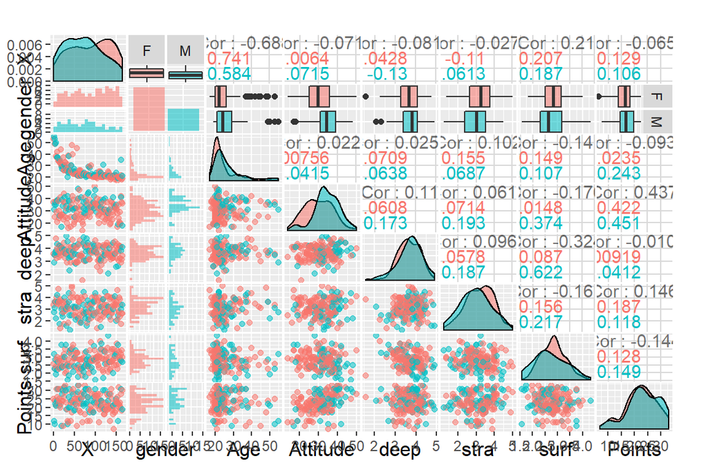

```r
ggpairs(learning2014, mapping = aes(col=gender, alpha=0.3), lower = list(combo = wrap("facethist", bins = 20)), progress=FALSE)
```

From the correlations we can see that attitude seems to have some correlation with exam points. This can also be seen from the scatterplots, where there seems to be a linear relationship between points and attitude.Other variables don’t seem to have clear correlation.

**Summaries of the data**

```r
summary(learning2014)
```

```
##        X          gender       Age           Attitude          deep
##  Min.   :  1.00   F:110   Min.   :17.00   Min.   :14.00   Min.   :1.583
##  1st Qu.: 42.25   M: 56   1st Qu.:21.00   1st Qu.:26.00   1st Qu.:3.333
##  Median : 83.50           Median :22.00   Median :32.00   Median :3.667
##  Mean   : 83.50           Mean   :25.51   Mean   :31.43   Mean   :3.680
##  3rd Qu.:124.75           3rd Qu.:27.00   3rd Qu.:37.00   3rd Qu.:4.083
##  Max.   :166.00           Max.   :55.00   Max.   :50.00   Max.   :4.917
##       stra            surf           Points
##  Min.   :1.250   Min.   :1.583   Min.   : 7.00
##  1st Qu.:2.625   1st Qu.:2.417   1st Qu.:19.00
##  Median :3.188   Median :2.833   Median :23.00
##  Mean   :3.121   Mean   :2.787   Mean   :22.72
##  3rd Qu.:3.625   3rd Qu.:3.167   3rd Qu.:27.75
##  Max.   :5.000   Max.   :4.333   Max.   :33.00
```

From the summaries (and plots) we can see that there is almost twize as much females as there are males. The mean age is 25.5 years, but the subjects varied from 17-55 years old.

**Regression model with three explanatory variables (attitude, stra and surf) and exam points as the target** The explanatory variables were chosen based on their correlation with the points in the plot matrix.

```r
model <- lm(Points~ Attitude + stra + surf, data= learning2014)
summary(model)
```

```
##
## Call:
## lm(formula = Points ~ Attitude + stra + surf, data = learning2014)
##
## Residuals:
##      Min       1Q   Median       3Q      Max
## -17.1550  -3.4346   0.5156   3.6401  10.8952
##
## Coefficients:
##             Estimate Std. Error t value Pr(>|t|)
## (Intercept) 11.01711    3.68375   2.991  0.00322 **
## Attitude     0.33952    0.05741   5.913 1.93e-08 ***
## stra         0.85313    0.54159   1.575  0.11716
## surf        -0.58607    0.80138  -0.731  0.46563
## ---
## Signif. codes:  0 '***' 0.001 '**' 0.01 '*' 0.05 '.' 0.1 ' ' 1
##
## Residual standard error: 5.296 on 162 degrees of freedom
## Multiple R-squared:  0.2074, Adjusted R-squared:  0.1927
## F-statistic: 14.13 on 3 and 162 DF,  p-value: 3.156e-08
```

From the summary, we can see that the only attitude has a statisticallyl significant effect on the model (p-value<<0.05). Hence we can remove stra and surf variables from the model. The significance of the individual coefficients of the variables is tested by using t-test, that compares each coefficient separately against the null hypothesis that the specific coefficeint would be zero.

We can also see that according to F-test, which tests the whole model against a model without any variables (=all coefficients are zero), the model is statistically signigficant (we can reject the null hypothesis that none of the variables would have any effect on points).

**New model with only attitude as a explanatory variable:**

```r
model <- lm(Points~ Attitude, data= learning2014)
summary(model)
```

```
##
## Call:
## lm(formula = Points ~ Attitude, data = learning2014)
##
## Residuals:
##      Min       1Q   Median       3Q      Max
## -16.9763  -3.2119   0.4339   4.1534  10.6645
##
## Coefficients:
##             Estimate Std. Error t value Pr(>|t|)
## (Intercept) 11.63715    1.83035   6.358 1.95e-09 ***
## Attitude     0.35255    0.05674   6.214 4.12e-09 ***
## ---
## Signif. codes:  0 '***' 0.001 '**' 0.01 '*' 0.05 '.' 0.1 ' ' 1
##
## Residual standard error: 5.32 on 164 degrees of freedom
## Multiple R-squared:  0.1906, Adjusted R-squared:  0.1856
## F-statistic: 38.61 on 1 and 164 DF,  p-value: 4.119e-09
```

We can see that the explanatory power of the model did not increase greatly (actually it decreased a bit according to the R-squared). However, the F-statistics became a bit better, and now we have less parameters that could increase the noise in the model.